# Analyis of Labour Market Transfer Agreements (LMTA) Client Numbers and Expenditures FY 2018-19 to FY 2023-24

Analytics Unit

October 31 2023

# Introduction

The purpose of this report is to undertake an analysis of past and present LMTA-claimed programs as well as labour market indicators, specifically client numbers and expenditures to serve clients. Another objective was to forecast expected LMTA client numbers and expenditures for the next five years. The forecast is important also in light of recent amendments to the EI act under Bill C-19. Under the Bill, the definition of an insured participant would be expanded to include more workers, and to remove the requirement that a person be unemployed. This is expected to increase LMTA client numbers and expenditures going forward. The information in this report will be used to inform discussion between the Ministry of Labour, Immigration, Training and Skills Development (MLITSD) and the Federal Government regarding projected LMTA client numbers and expenditures.

# Data

Data used for the purpose of this report includes both MLITSD’s internal resources and external resources.

## MLITSD Resources

The following data sets were obtained from the System, Planning and Reporting Unit (SPRU), which is the owner of LMTA data shared with the Federal Government.

1. LMTA claim expenditures and client numbers from FY 2018-19 till Q1 of FY 2023-24 by programs under the following categories:
   1. Employment Services Transformation
   2. Apprenticeship
   3. Core Training Programs
   4. Project-Based Programs
   5. Labour Market Programs
   6. Other Government Priorities
   7. Programs that are not continued
   8. Other Programs Supported by time-limited COVID Response Funding

Note:

```
* This includes programs that are case managed in CaMs or APPR and does not include WPID projects or grants or programs claimed under the Labour Market Partnership bucket such as COJG, SAO, SDF.

* LMTA consists of claims under Labour Market Development Agreements(LMDA) and Workforce Develpoment Agreements (WDA), which together form the overall claims under LMTA.
```

2. EI eligibility data from FY 2018-19 till FY 2022-23 by programs

## External Resources:

A number of external resources were used which have been referenced in the text and links to all of these resources have been provided in the Appendix.

## Data Quality

- LMTA claims and EI eligibility data between the past five years was used i.e. FY 2018-19 and Q1 of FY 2022-24. Within this time frame, the pandemic and ensuing lock downs had a substantial impact on the overall economy and on the labour market. This impact can be seen in the client data used for the purpose of this report. The magnitude and direction of the impact for various metrics will be discussed in detail below.
- Data with a sufficient number of data points is required for quantitative forecasting of EO clients and LMTA claims. Since the EI eligibility as well as LMTA claims are reported yearly there were not enough data points for the five years considered. Using outdated data older than five years for forecasting would have led to biased results. Therefore, a qualitative forecasting approach based on outlook for the labour market was used as reported under “Methodology” below.

# Methodology:

- External resources are used to highlight outlook for the overall economy and the labour market for the next five years
- Data for number of EI eligible and non EI eligible clients is used to determine trends in EO client numbers. Forecast for EO client numbers made based on outlook for the labor market.
- Forecasts for EO client numbers and data for LMTA claim numbers and expenditures will be used to determine trends in LMTA claims and expenditures.

# State of the Economy and Labor Market; Forecasts for FY 2024-25 till FY 2029-30

Starting in March 2022, Bank of Canada (BoC) has delivered 10 increases in its policy rate, totaling 475 basis points. Canada has the third highest household debt to GDP ratio in the G20, after Switzerland and Australia. This means that Canadians are highly vulnerable to increases in interest rate payments as a result of BoC’s rate hikes. This has resulted in softer household spending, weaker economic growth and a labour market so far showing signs of easing.

Despite the increase in BoC’s policy rate, inflation has not come down as much as expected. After falling to 2.8% in June 2023, it creeped up again to 4% in August and 3.8% in September. The BoC projects that inflation will stay around 3.5% until the middle of 2024 and will return to its 2% target by the end of 2025. Consumers’ inflation expectations also remain higher than they were before the pandemic, averaging 5% over the next year and 4% for the year beyond that.

Unfortunately, in order for inflation to reach BoC’s 2% target, the economy will need to slow down as well. The lagged nature of the impact of BoC policy rate increases also means that much of the slowdown in economic growth as a result of interest rate hikes is yet to come.

There are different predictions of how long the slowdown in economic growth will last. BoC predicts that GDP growth per capita will remain subdued for all of 2024. Deloitte also predicts no growth in GDP per capita till the latter half of 2024 and a slow recovery after that. It also reported that improved outlook for the trade sector, continued strong population growth and end in the BoC’s rate hike cycle are playing important roles in avoiding a deeper recession.

All of this has started to impact the labor market. Highlights from the Strategic Policy Division’s latest report for Labour Market Conditions in Ontario for the third Quarter of 2023 and September 2023 show:

- Ontario’s unemployment rate rose from 5.9% in August to 6.0% in September as the number of unemployed rose by 3,100.
- September’s unemployment rate was the highest rate recorded since January 2022 and exceeded the February 2020 pre-COVID rate of 5.6%.
- Ontario’s vacancy rate fell to 3.9% in the second quarter of 2023, the fourth consecutive quarterly drop from a record high of 5.6%, as the number of unfilled jobs fell by 9.3%.

## EI Eligible, Non-Eligible Clients

Figure 1 below shows trend for number of EI eligible clients. There is a decreasing trend partly due to the decrease in overall client numbers during the pandemic.

Also, EI benefits are paid for up to 45 weeks in Ontario. Clients who became unemployed early on in the pandemic would have used their EI benefits and become ineligible thereafter.

However, the low numbers of EI eligible clients have continued post pandemic as well, which could be a result of irregular employment in the gig economy and higher turnover due to the sudden increase in job openings after the pandemic.

Note:

```
* For simplicity of notation, FY 2018-19 has been termed as "2019", FY 2019-20 as  "2020", and so on.
```

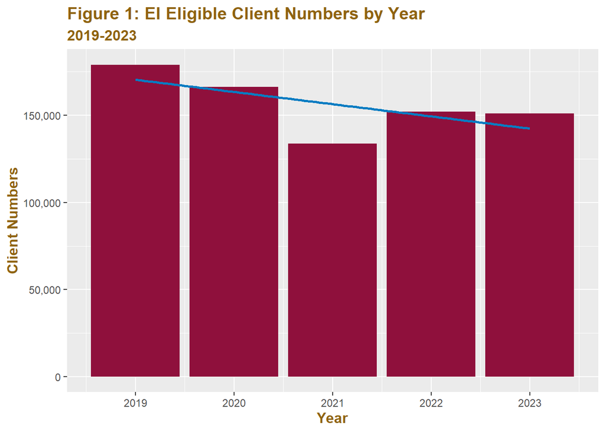

Table 1 below shows the actual numbers of EI eligible clients by year. The decreasing trend is evident looking at the numbers as well.

| Year | Number of Clients |
| --- | --- |
| 2019 | 179002 |
| 2020 | 166439 |
| 2021 | 133801 |
| 2022 | 152047 |
| 2023 | 151108 |

Forecast:

*The outlook for the Canadian economy discussed above showed that we expect GDP growth to remain subdued at least till the end of FY 2024-25. As can be seen in Figure 1, when GDP contracts, as happened during the pandemic years, number of EI eligible clients decrease. Therefore, forecast for the number of EI eligible clients is that they will start decreasing at the end of FY 2023-24 till end of FY 2024-25. Thereafter,client numbers may increase or remain low based on speed of economic recovery*

Figure 2 below shows trend for number of ‘non-EI eligible’ clients, which is an important variable, given the amendments to the EI act under Bill C-19.

Under the Bill, the definition of an insured participant would be expanded to include more workers, and to remove the requirement that a person be unemployed.This would potentially add a number of clients who are currently under the non-EI eligible category to the EI eligible category.

The bar chart on the left shows the overall trend between FY 2018-19 till FY 2022-23. There is a decreasing trend overall.

The bar chart on the right shows the trend between FY 2020-21 and FY 2022-23 i.e. last three years. The trend for the last three years has been increasing, showing that the client numbers are quickly returning to pre pandemic levels.

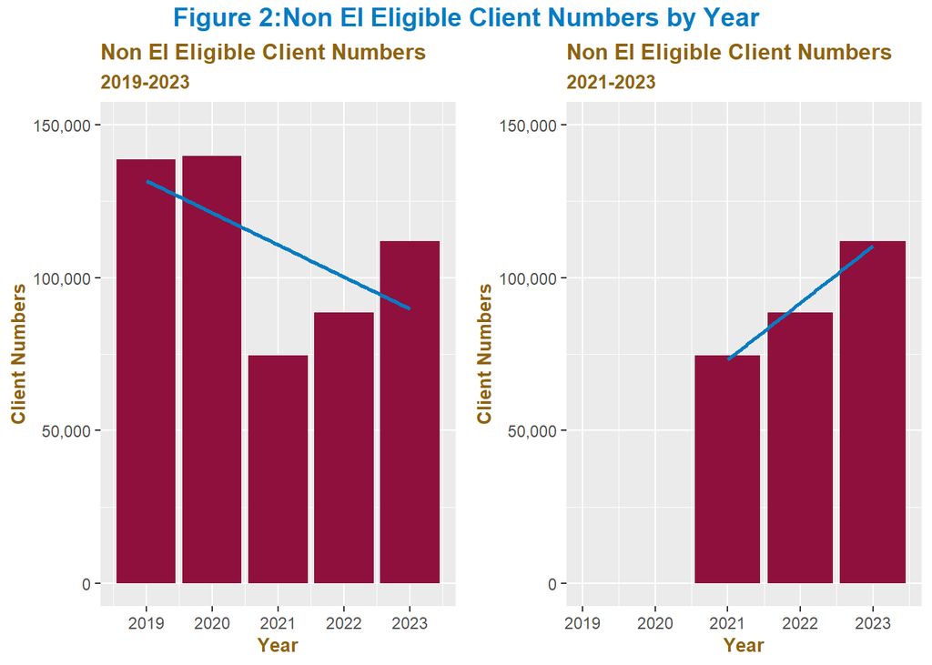

| Year | Number of Clients |
| --- | --- |
| 2019 | 138711 |
| 2020 | 139708 |
| 2021 | 74654 |
| 2022 | 88633 |
| 2023 | 111846 |

Forecast:

*As can be seen in Figure 2 above, when GDP contracts, as happened during the pandemic years, number of non EI eligible clients decrease. Therefore, forecast for the number of non EI eligible clients is that they will start decreasing at the end of FY 2023-24 till end of FY 2024-25. Thereafter, client numbers may increase or remain low based on speed of economic recovery*

Figure 3 below shows the sum of EI eligible and non EI eligible clients by year, which is the main variable of interest given the amendments to the EI act discussed above. Given that the definition of an insured participant is being expanded to include more workers, we could potentially see a number of clients who are currently under the non EI eligible category being added to the EI eligible category.

Therefore, the current sum of EI eligible and non EI eligible clients provides a good estimate of the expected number of EI eligible clients who will also be eligible for LMTA claims.

This sum excludes those who did not have a SIN or had an invalid SIN. Therefore these clients were not counted under EI eligible nor under the ‘non EI eligible’ category. Some of these people may have a valid SIN in the years ahead and become EI eligible. However, it is impossible to estimate the number of these people and therefore have been excluded.

The bar chart on the left shows a decreasing trend but mainly due to low client numbers during the pandemic. The bar chart on the right shows an increasing trend for the three most recent years.

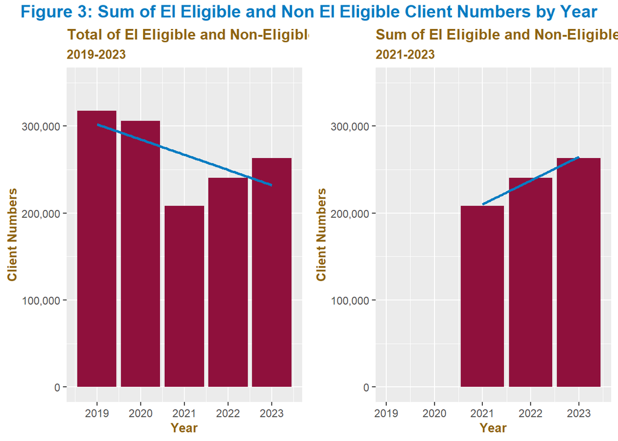

| Year | Number of Clients |
| --- | --- |
| 2019 | 317713 |
| 2020 | 306147 |
| 2021 | 208455 |
| 2022 | 240680 |
| 2023 | 262954 |

Forecast:

*Despite the increasing trend for the sum of EI eligible and non EI eligible clients in the three most recent years, the forecast for the same is to decrease at least till the end of FY 2024-25. Figure 1 and Figure 2 showed that when GDP contracts, as happened during the pandemic years, numbers of both EI eligible and non EI eligible clients decrease. Therefore, forecast for the sum of EI eligible and non EI eligible clients is that it will also start decreasing at the end of FY 2023-24 till end of FY 2024-25. Thereafter, client numbers may increase or remain low based on speed of economic recovery.*

# LMTA Claims

## Claim Numbers

Figure 5 below shows LMTA claim numbers for each of the years from FY 2018-19 till FY 2022-23. The trend line shows a slight increase in claims. Claims fell in FY 2019-20 and FY 2020-21 but recovered thereafter and reached pre pandemic levels. In fact, claims for the most recent FY 2022-23 are higher than claims in FY 2018-19 as shown in Table 5 below.

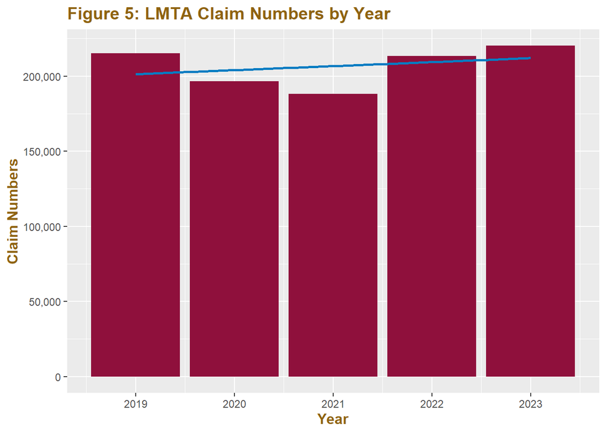

| Year | Claim Number |
| --- | --- |
| 2019 | 215232 |
| 2020 | 196615 |
| 2021 | 188049 |
| 2022 | 213396 |
| 2023 | 220145.566734395 |

Forecast:

*Figure 5 shows that when GDP contracts, LMTA claims decrease. Therefore, forecast for LMTA claims is to decrease at least till the end of FY 2024-25*

## Claim Expenditure

Figure 6 below shows LMTA claim expenditure for each of the years from FY 2018-19 till FY 2023-24.

The bar chart on the left shows an increasing trend in claim expenditure. Claim expenditure during FY 2020-21 and FY 2021-22 is higher than the overall trend. This increase in claim expenditure, despite the fall in claim numbers around the same time shown in Figure 5, could have been a result of more intensive and longer duration of employment services required for clients during the pandemic.

[figure not shown]

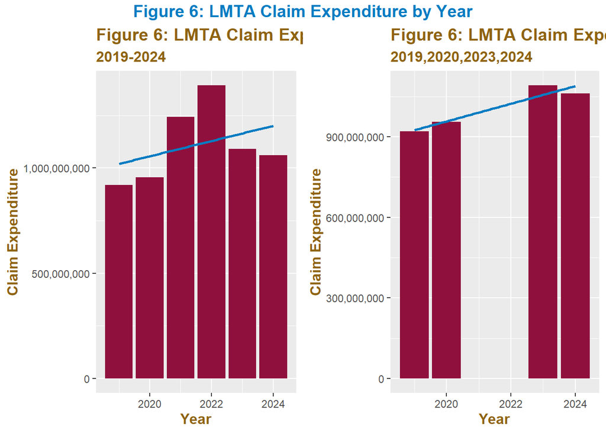

| Year | Claim Expenditure |
| --- | --- |
| 2019 | 920000000 |
| 2020 | 955100000 |
| 2021 | 1242700000 |
| 2022 | 1393000000 |
| 2023 | 1091800000 |
| 2024 | 1061400000 |

*Figure 6 shows that when GDP contracts, LMTA claim expenditures increase. Therefore, forecast for LMTA claim expenditures is to increase at least till the end of FY 2024-25. Since the current data from FY 2018-19 till FY 2023-24 also shows an increasing trend in LMTA claim expenditure, both factors (i.e. current trend and expected unemployment) will combine to produce an significant increase in claim expenditure till end of FY 2024-25.Thereafter, claim expenditures may decrease or remain elevated based on speed of economic recovery.*

# Appendix

1. https://www2.deloitte.com/content/dam/Deloitte/ca/Documents/finance/ca-economic-outlook-september-2023-report-aoda-en.pdf
2. https://www.conferenceboard.ca/in-fact/canadas-five-year-outlook-overview-labour-market_oct2023/
3. https://www.bankofcanada.ca/2023/10/mpr-2023-10-25/
4. https://ontariogov.sharepoint.com/sites/LMReport/SitePages/Labour-Market.aspx?web=1
5. https://www150.statcan.gc.ca/n1/daily-quotidien/230908/dq230908a-eng.htm?HPA=1&indid=3587-2&indgeo=0